# Aside

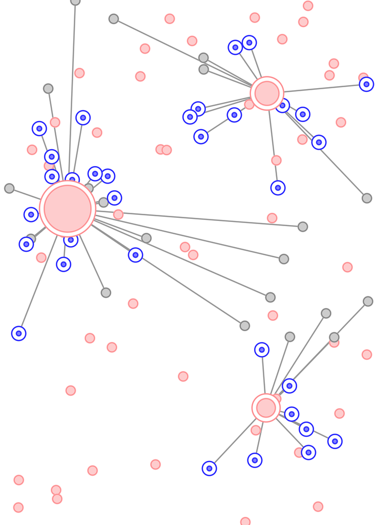

[Download this CV as a PDF](https://github.com/bmbrost/cv/brost_cv.pdf)

## Contact

- Durango, CO
- bmbrost@gmail.com
- +1 (928) 814-9703
- linkedin.com/in/bmbrost/
- [scholar.google.com/. . .](https://scholar.google.com/citations?user=QAGvJAEAAAAJ&hl=en#)

## Technical Skills

- **Tools:** R, Stan, NIMBLE, GitHub, Quarto, Markdown, LATEX, Adobe Creative Suite, Python, SQL, basic HTML & CSS
- **Statistics:** Bayesian hierarchical models, GLMMs, GAMs, HMMs, spatio-temporal models, machine learning, contemporary non-parametrics, frequentist statistics and maximum likelihood estimation
- **GIS:** ArcGIS, QGIS, R (e.g., packages *sf* and *terra*)

## Disclaimer

Updated 2025-10-29

# Main

## Brian Brost

**Statistics + Spatial Analysis + Data Visualization**

Data scientist, applied statistician, and spatial analyst with 15+ years of experience finding the signal in a noisy world. Highly skilled in advanced analytical techniques—including contemporary Bayesian hierarchical models—that turn complex (and often messy) data into discovery. Passionate about conveying stories through high-quality graphics and cartographic design. Motivated by challenging problems and a desire to leave the world a little better than I found it.

## Education

### **Ph.D., Ecology**

Colorado State University

Fort Collins, CO

2017 - 2012

- Research topic: Developing “boutique” hierarchical spatio-temporal models for complex ecological processes
- Dissertation: *Statistical models for animal telemetry data with applications to harbor seals in the Gulf of Alaska* (pdf)
- Advisor: Mevin Hooten

### **M.S., Conservation Biology**

Northern Arizona University

Flagstaff, AZ

2010 - 2007

- Research topic: Conservation planning strategies for global climate change
- Thesis: *Use of land facets to design conservation corridors: Conserving the arenas, not the actors* (pdf)
- Advisor: Paul Beier

### **Graduate Certificate in Applied Statistics**

Northern Arizona University

Flagstaff, AZ

2009 - 2007

- Coursework: regression analysis, time series analysis, quantitative biology, multivariate statistics, applied sampling, applied community analysis, and ecological modeling

### **B.S., Zoology and Conservation Biology**

University of Wisconsin-Madison

Madison, WI

2002 - 1999

- Senior thesis: Characteristics of wolf packs that depredate livestock in Wisconsin, USA

## Professional Experience

### **Statistician (Biology)**

National Oceanic and Atmospheric Administration

Durango, CO (Remote)

2025 - 2017

- Led quantitative ecological research and supported a team of ~20 biologists with statistical modeling, spatial analysis, study design, and data management expertise.
- Developed Bayesian hierarchical models for enhanced inference, addressing complexities like measurement error, imperfect observations, missing data, and autocorrelation.
- Analyzed monitoring data to estimate the abundance, survival, habitat use, and distribution of marine mammals.
- Led efforts to estimate marine mammal mortalities incidental to commercial fishing, improving inference and uncertainty accounting.
- Managed a research program investigating movements of northern fur seals using a large instrument array distributed across multiple remote islands.
- Assisted in interpreting complex statistical methodologies, ensuring clarity in technical writing and graphical outputs for publications.

### **Graduate Research Assistant**

Colorado State University

Fort Collins, CO

2017 - 2012

- Designed and conducted original research on the spatial ecology of harbor seals in Alaska.
- Developed “boutique” Bayesian spatio-temporal models, including custom software and bespoke MCMC algorithms for model implementation.
- Created statistical methodologies for analyzing biotelemetry data while accounting for locational error, missing data, autocorrelation, and movement constraints.
- Applied novel Bayesian nonparametrics to estimate the location of harbor seal haul-out sites, integrating multiple data sources.

### **Biometrician**

Great Lakes Indian Fish & Wildlife Commission

Odanah, WI

2012 - 2010

- Provided statistical support to a team of wildlife ecologists, fisheries biologists, and botanists.
- Assessed factors affecting rest site selection by American marten, quantified resource selection by elk, and modeled mercury concentration in walleye to establish consumption guidelines (among other projects).
- Developed and managed PostgreSQL databases for efficient data storage and retrieval.

### **Graduate Research Assistant**

Northern Arizona University

Flagstaff, AZ

2010 - 2007

- Developed an innovative method for modeling conservation corridors utilizing topography instead of factors like vegetation that are sensitive to climate.
- Conducted a formal evaluation of corridor modeling approaches to identify best practices.

### **Biological Research Technician**

Multiple agencies and non-governmental organizations

CA, MT, NV, WY, WA

2007 - 2003

Participated in various plant- and animal-related fieldwork projects. Duties included:

- Supervised field operations, established sampling priorities, developed field protocols, conducted quality control, and interviewed/hired/trained > 20 field technicians (as Project Coordinator and Crew Leader).
- Conducted wildlife surveys, collected genetic samples using non-invasive techniques, captured/handled animals, studied animal behavior, and mapped vegetative and abiotic land cover (as Crew Member).

## Publications

### Sterling, J.T., and B.M. Brost. Summer resource limitation as a likely mechanism impacting northern fur seal (*Callorhinus ursinus*) recovery.

N/A

N/A

In prep.

### Brost, B.M, and N. Young. Hierarchical models improve inference concerning marine mammal mortalities incidental to commercial fishing activities.

N/A

N/A

In prep.

### Zeppelin, T.K., B.M. Brost, D.S. Johnson, C.M. Kurle, B.A. Güell, C. Keller, M.T. Williams, and A.E. York. Determining cryptic life history milestones using isotopic markers in northern fur seal (*Callorhinus ursinus*) vibrissae.

N/A

N/A

In review

### Conn, P.B., J.M. Ver Hoef, B.T. McClintock, D.S. Johnson, and B. Brost. A GLMM approach for combining multiple relative abundance surfaces. *Methods in Ecology and Evolution* **13**:2236–2247. [(pdf)](https://bmbrost.github.io/publications/Conn_et_al_MEE_2022.pdf)

N/A

N/A

2022

### Johnson, D.S., B.M. Brost, and M.B. Hooten. Greater than the sum of its parts: computationally flexible Bayesian hierarchical modeling. *Journal of Agricultural, Biological, and Environmental Statistics* **27**:382–400. [(pdf)](https://bmbrost.github.io/publications/Johnson_et_al_JABES_2022.pdf)

N/A

N/A

2022

### Hooten, M.B., D.S. Johnson, and B.M. Brost. Making recursive Bayesian inference accessible. *The American Statistician* **75**:185–194. [(pdf)](https://bmbrost.github.io/publications/Hooten_et_al_AmStat_2021.pdf)

N/A

N/A

2021

### Brost, B.M., M.B. Hooten, and R.J. Small. Model-based clustering reveals patterns in central place use of a marine top predator. *Ecosphere* **11**(6):e03123. [(pdf)](https://bmbrost.github.io/publications/Brost_et_al_Ecosphere_2020.pdf)

N/A

N/A

2020

### Fritz, L., B. Brost, E. Laman, K. Luxa, K. Sweeney, J. Thomason, D. Tollit, W. Walker, and T. Zeppelin. A re-examination of the relationship between Steller sea lion (*Eumetopias jubatus*) diet and population trend using data from the Aleutian Islands. *Canadian Journal of Zoology* **97**:1137–1155. [(pdf)](https://bmbrost.github.io/publications/Fritz_et_al_CJZ_2019.pdf)

N/A

N/A

2019

### Zeppelin, T., N. Pelland, J. Sterling, B. Brost, S. Melin, D. Johnson, M. Lea, and R. Ream. Migratory strategies of juvenile northern fur seals (*Callorhinus ursinus*): bridging the gap between pups and adults. *Scientific Reports* **9**:13921. [(pdf)](https://bmbrost.github.io/publications/Zeppelin_et_al_SciReports_2019.pdf)

N/A

N/A

2019

### Brost, B.M., B.A. Mosher, and K.A. Davenport. A model-based solution for observational errors in laboratory studies. *Molecular Ecology Resources* **18**:580–589. [(pdf)](https://bmbrost.github.io/publications/Brost_et_al_MER_2018.pdf)

N/A

N/A

2018

### Davenport, K.A., B.A. Mosher, B.M. Brost, D.M. Henderson, N.A. Denkers, A.V. Nalls, E. McNulty, C.K. Mathiason, and E.A. Hoover. Assessment of chronic wasting disease prion shedding in deer saliva with occupancy modeling. *Journal of Clinical Microbiology* **56**:e01243–17. [(pdf)](https://bmbrost.github.io/publications/Davenport_et_al_JCM_2018.pdf)

N/A

N/A

2018

### Brost, B.M., M.B. Hooten, and R.J. Small. Leveraging constraints and biotelemetry data to pinpoint repetitively used spatial features. *Ecology* **98**:12–20. [(pdf)](https://bmbrost.github.io/publications/Brost_et_al_Ecology_2017.pdf)

N/A

N/A

2017

### Hefley, T.J., K.M. Broms, B.M. Brost, F.E. Buderman, S.L. Kay, H.R. Scharf, J.R. Tipton, P.J. Williams, and M.B. Hooten. The basis function approach for modeling autocorrelation in ecological data. *Ecology* **98**:632–646. [(pdf)](https://bmbrost.github.io/publications/Hefley_et_al_Ecology_2017.pdf)

N/A

N/A

2017

### Hefley, T.J., B.M. Brost, and M.B. Hooten. Bias correction of bounded location errors in presence-only data. *Methods in Ecology and Evolution* **8**:1566–1573. [(pdf)](https://bmbrost.github.io/publications/Hefley_et_al_MEE_2017.pdf)

N/A

N/A

2017

### Small, R.J., B. Brost, M. Hooten, M. Castellote, and J. Mondragon. Potential for spatial displacement of Cook Inlet beluga whales by anthropogenic noise in critical habitat. *Endangered Species Research* **32**:43–57. [(pdf)](https://bmbrost.github.io/publications/Small_et_al_ESR_2017.pdf)

N/A

N/A

2017

### Hooten, M.B., F.E. Buderman, B.M. Brost, E.M. Hanks, and J.S. Ivan. Hierarchical animal movement models for population-level inference. *Environmetrics* **27**:322–333. [(pdf)](https://bmbrost.github.io/publications/Hooten_et_al_Environmetrics_2016.pdf)

N/A

N/A

2016

### Brost, B.M., M.B. Hooten, E.M. Hanks, and R.J. Small. Animal movement constraints improve resource selection inference in the presence of telemetry error. *Ecology* **96**:2590–2597. [(pdf)](https://bmbrost.github.io/publications/Brost_et_al_Ecology_2015.pdf)

N/A

N/A

2015

### Brost, B.M., and P. Beier. Comparing linkage designs based on land facets to linkage designs based on focal species. *PLoS One* **7**:e48965. [(pdf)](https://bmbrost.github.io/publications/Brost_Beier_PONE_2012.pdf)

N/A

N/A

2012

### Brost, B.M., and P. Beier. Use of land facets to design linkages for climate change. *Ecological Applications* **22**:87–103. [(pdf)](https://bmbrost.github.io/publications/Brost_Beier_EcolApps_2012.pdf)

N/A

N/A

2012

### Beier, P., and B. Brost. Use of land facets to plan for climate change: Conserving the arenas, not the actors. *Conservation Biology* **24**:701–710. [(pdf)](https://bmbrost.github.io/publications/Beier_Brost_ConsBio_2010.pdf)

N/A

N/A

2010

### McMaster, M.A., A. Thode, B. Brost, M. Williamson, E. Aumack, D. Mertz. Changes in vegetation and fuels due to the Warm Fire on the Kaibab National Forest. *Joint Fire Science Program Research Project Reports* 34. [(pdf)](https://bmbrost.github.io/publications/McMaster_et_al_JFSP_2010.pdf)

N/A

N/A

2010

### Wydeven, A.P., A. Treves, B. Brost, and J.E. Wiedenhoeft. Characteristics of wolf packs in Wisconsin: Identification of traits influencing depredation. In *People and Predators: From Conflict to Coexistence,* eds. N. Fascione, A. Delach, and M. E. Smith. Island Press, Washington, D.C. [(pdf)](https://bmbrost.github.io/publications/Wydeven_et_al_preprint_2004.pdf)

N/A

N/A

2004